# Soundscape Inventory Report

Cordell Bank National Marine Sanctuary - Ocean Noise Reference Station

2025-02-21

# **What is ocean sound?**

Ocean sound refers to the collection of acoustic energy present in marine environments, encompassing a variety of sources, including sounds from marine animals, geophysical noise from waves, wind, rain, and human generated noise from shipping, sonar, and offshore construction. Monitoring ocean sound provides key insight to understanding ecosystem dynamics, detecting environmental changes, and managing the impacts of noise pollution on marine organisms. Learn more at [Discovery of Sound in the Sea](https://dosits.org/)

**Why do we care?** Ocean sound is critical for the survival of many marine animals because it is a primary means of communication, orientation and navigation, finding food, avoiding predators, and choosing mates. As such, human activities that produce underwater sounds have the potential to negatively impact animals by reducing their ability to hear prey, predators, and each other. National marine sanctuaries are home to many acoustically active marine animals and understanding the presence and impacts of noise is a conservation priority. Further, the occurrence and types of sounds present offer key insights on animal presence, species behaviors, human-use patterns, and changing ocean conditions.

# **When, where, and why are we listening?**

NOAA’s Office of National Marine Sanctuaries maintains a nationally coordinated underwater sound monitoring network across the National Marine Sanctuary System, known as ONMS Sound. ONMS works with partners to monitor [sound within national marine sanctuaries](https://sanctuaries.noaa.gov/science/monitoring/sound/). Ocean Sound monitoring sites are located in strategic locations within sanctuary boundaries and record continuously. Audio recordings and standardized sound measurements are available through the NOAA National Centers for Environmental Information’s Passive Acoustic Archive. Explore the monitoring sites [here](https://www.ncei.noaa.gov/maps/passive-acoustic-data/).

The **Cordell Bank National Marine Sanctuary** (CBNMS) is entirely offshore. Within its 1,286 square miles, the sanctuary protects soft seafloor habitat, a rocky bank, deep sea canyons, and communities of wildlife throughout. Its surface waters are feeding areas for local and migratory seabirds and marine mammals.

| Site | Primary.monitoring.purpose | Oceanographic.Setting | Seasonality | Vessel.Traffic.Setting | Latitude | Longitude | Region | Sanctuary | TotalDays | StartDate | Learn.more..website |
| --- | --- | --- | --- | --- | --- | --- | --- | --- | --- | --- | --- |
| NRS11 | To continue long-history of monitoring trends in ocean noise, including cetacean species presense and vessel movement | Continental slope (>200m), exposed to deep-water | Seasonal patterns driven by known sounds from baleen whales | Constant large vessel activity - in traffic fan approaching San Fran/Oakland | 37.88082 | -123.4353 | West Coast | CB | 1433 | 2015-10-17 | https://soundcoop.portal.axds.co/#soundcoop/datasets/NRS11 |

# **Summary of Monitoring Effort**

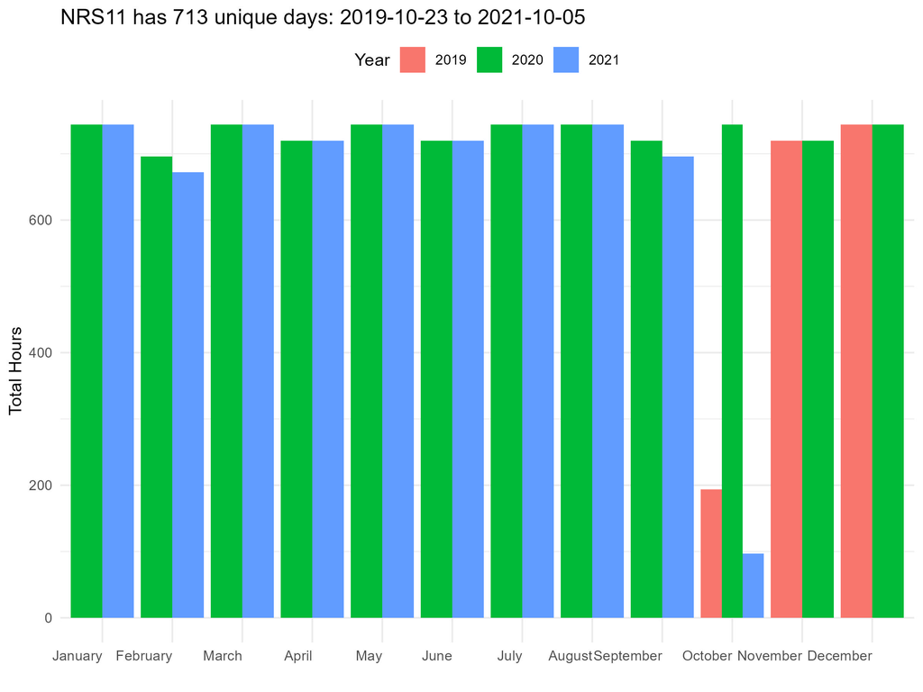

[figure not shown]

# **What sounds contribute to the soundscape?**

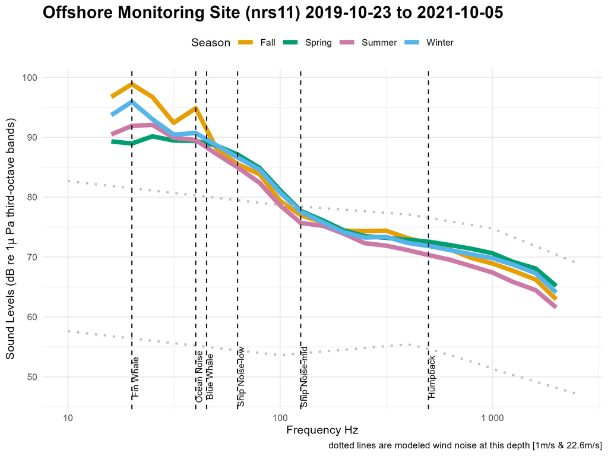